# PR1

8/24/2015

### ISCAM Investigation B: Random Babies

1. After at least 1000 trials, complete the table below.

```r
> babies <- c("Marvin", "Willie", "Billy", "Sam")
> nights <- 1000
> NumberCorrect <- numeric(nights)
> for(i in 1:nights){
+   shuffle <- sample(babies, size = 4, replace = FALSE)
+   NumberCorrect[i] <- sum(babies == shuffle)
+ }
> xtabs(~NumberCorrect)
```

```
NumberCorrect
  0   1   2   4
358 345 260  37
```

```r
> TAsi <- xtabs(~NumberCorrect)/nights
> TAsi
```

```
NumberCorrect
    0     1     2     4
0.358 0.345 0.260 0.037
```

*The R simulation with 1,000 trials/nights returns and estimated probability that zero mothers receive their own baby of 0.358.*

15. How many different outcomes are there for returning four babies to their mothers? What is each outcome’s probability of occurring for any trial?

```r
> library(combinat)
> library(MASS)
> Omega <- permn(babies)
> n <- length(Omega)
> NumberCorrect <- numeric(n)
> for(i in 1:n){
+ NumberCorrect[i] <- sum(Omega[[i]] == babies)
+ }
> FA <- xtabs(~NumberCorrect)/n
> FA
```

```
NumberCorrect
         0          1          2          4
0.37500000 0.33333333 0.25000000 0.04166667
```

```r
> TA <- fractions(xtabs(~NumberCorrect)/n)
> TA
```

```
NumberCorrect
   0    1    2    4
 3/8  1/3  1/4 1/24
```

*There are 24 possible outcomes for returning the four babies to their mothers. The possible outcomes are stored in the variable `Omega`. The probability of each outcome of occurring for any trial is $\frac{1}{24}$.*

```r
> Omega
```

```
[[1]]
[1] "Marvin" "Willie" "Billy"  "Sam"

[[2]]
[1] "Marvin" "Willie" "Sam"    "Billy"

[[3]]
[1] "Marvin" "Sam"    "Willie" "Billy"

[[4]]
[1] "Sam"    "Marvin" "Willie" "Billy"

[[5]]
[1] "Sam"    "Marvin" "Billy"  "Willie"

[[6]]
[1] "Marvin" "Sam"    "Billy"  "Willie"

[[7]]
[1] "Marvin" "Billy"  "Sam"    "Willie"

[[8]]
[1] "Marvin" "Billy"  "Willie" "Sam"

[[9]]
[1] "Billy"  "Marvin" "Willie" "Sam"

[[10]]
[1] "Billy"  "Marvin" "Sam"    "Willie"

[[11]]
[1] "Billy"  "Sam"    "Marvin" "Willie"

[[12]]
[1] "Sam"    "Billy"  "Marvin" "Willie"

[[13]]
[1] "Sam"    "Billy"  "Willie" "Marvin"

[[14]]
```

[output cut: 16 more lines]

```

[[20]]
[1] "Sam"    "Willie" "Billy"  "Marvin"

[[21]]
[1] "Sam"    "Willie" "Marvin" "Billy"

[[22]]
[1] "Willie" "Sam"    "Marvin" "Billy"

[[23]]
[1] "Willie" "Marvin" "Sam"    "Billy"

[[24]]
[1] "Willie" "Marvin" "Billy"  "Sam"
```

### ISCAM Investigation 1.1: Friend or Foe?

1. What proportion of these infants chose the helper toy? Is this more than half (majority)? Also sketch by hand a simple bar group to display the results for this sample (one bar for each toy, with heights representing the proportion of times that toy was picked, bars are separated).

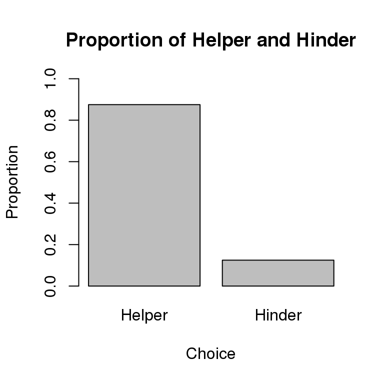

```r
> HH <- c(0.875,0.125)
> barplot(HH, main="Proportion of Helper and Hinder", xlab="Choice", ylab="Proportion", names.arg=c("Helper","Hinder"),
+ border="black",ylim = c(0, 1))
```

*Proportion? These infants chose the helper toy at the proportion of .875.*

*Majority? .875 > .5 so this is definitely a majority.*

6. Explain why looking at such “could have been” results will be useful to us.

*The “could have been” results will provide a good demonstration of how a true random simulation would result in. A bell curve with the center around 8 is it’s graphical representation. Consequently, the “could have been” results would show how the 14 out of 16 as a result would rarely occur.*

7. Flip a coin 16 times, representing the 16 infants in the study (one *trial* or *repetition* from this random process). Let a result of heads mean that the infant chooses the helper toy, tails for the hinderer toy. Tally the results below and count how many of the 16 chose the helper toy:

```r
> simulation <- sample(c("Head", "Tail"), 16, replace = TRUE)
> heads <- sum(simulation=="Head")
> xtabs(~simulation)
```

```
simulation
Head Tail
   9    7
```

*There were 9 heads for the total number of heads in 16 tosses.*

8. Repeat this two more times. Keep track of how many infants, out of the 16, choose the helper. Record this number for all three of your repetitions (including the one from the previous question):

```r
> a <-sample(c("Helper", "Hinderer"), 16, replace=TRUE)
> ahelpers <-sum(a=="Helper")
>
> b <-sample(c("Helper", "Hinderer"), 16, replace=TRUE)
> bhelpers <-sum(b=="Helper")
>
> c <-sample(c("Helper", "Hinder"), 16, replace=TRUE)
> chelpers <-sum(c=="Helper")
```

[output not shown]

12. Use the One Proportion Inference applet to simulate these 16 infants making this helper/hinderer choice, still assuming the null model that infants have no real preference and so are equally likely to choose either toy. Report the number of heads (i.e., the number of infants who choose the helper toy) for this “could have been” (nder the null model) outcome.

```r
> d <-sample(c("Helper", "Hinderer"), 16, replace=TRUE)
> dhelpers <-sum(d=="Helper")
```

*There were 9 heads for the “could have been” outcome.*

13. **Uncheck** the **Animate** box and press **Draw Samples** four more times, each time recording the number of the 16 infants who choose the helper toy. Did you get the same number of heads all five times?

```r
> a1 <-sample(c("Helper", "Hinderer"), 16, replace=TRUE)
> a1helpers <-sum(a1=="Helper")
>
> b1 <-sample(c("Helper", "Hinderer"), 16, replace=TRUE)
> b1helpers <-sum(b1=="Helper")
>
> c1 <-sample(c("Helper", "Hinder"), 16, replace=TRUE)
> c1helpers <-sum(c1=="Helper")
>
> d1 <-sample(c("Helper", "Hinderer"), 16, replace=TRUE)
> d1helpers <-sum(d1=="Helper")
```

| Repetition # | 1 | 2 | 3 | 4 | 5 |
| --- | --- | --- | --- | --- | --- |
| **Number of Heads** | *9* | *9* | *10* | *9* | *7* |

### RR Chapter 1 & 2

Chapter 1 of *Reproducible Research with R and Rstudio* introduced the readers to the practice of reproducible research whose results are generally and scientifically regarded as replicable having enough information for independent researchers to make similar findings with the new data using the same procedures. The author claimed that research should be reproducible to benefit science generally and you specifically. For science, reproducibility enhances replicability which opens claims to scrutiny that is important for evaluating scientific claims and reproducibility help researchers avoid duplicating efforts while invigorating cumulative growth of scientific knowledge. For you, producing a reproducible research helps you to have a better work habits, better teamwork, higher research impact, and can easily implement changes in the process. The author also touched on who should read this book and recommended the research tools needed for reproducible research that this book would use including R, knitr & rmarkdown, markup languages, RStudio, Cloud storage & versioning, and Unix-like shell programs and how they should be used for reproducible research. Chapter 2 first talked about the big picture as a workflow for reproduce research and introduced practical tips for reproducible research. In my opinions,those tips listed were really applicable and applicable especially document everything and all files should be human readable in order to make those files reproducible and available in the future for further work, researches, and collaboration with other people.